# Practicum 1 - Taylor Johnson

## Problem 1 (60 Points)

### Question 1

(0 pts) Download the data set UCI Heart Disease.

```r
heart_data <- read.csv("/Users/taylorjohnson/Downloads/Heart_Disease_Dataset/heart.csv", stringsAsFactors =F)
```

### Question 2

(1 pts) Explore the data set to get a sense of the data and to get comfortable with it. Use the names file to understand the columns present in the data.

```r
str(heart_data)
```

```
## 'data.frame':    303 obs. of  14 variables:
##  $ age     : int  63 37 41 56 57 57 56 44 52 57 ...
##  $ sex     : int  1 1 0 1 0 1 0 1 1 1 ...
##  $ cp      : int  3 2 1 1 0 0 1 1 2 2 ...
##  $ trestbps: int  145 130 130 120 120 140 140 120 172 150 ...
##  $ chol    : int  233 250 204 236 354 192 294 263 199 168 ...
##  $ fbs     : int  1 0 0 0 0 0 0 0 1 0 ...
##  $ restecg : int  0 1 0 1 1 1 0 1 1 1 ...
##  $ thalach : int  150 187 172 178 163 148 153 173 162 174 ...
##  $ exang   : int  0 0 0 0 1 0 0 0 0 0 ...
##  $ oldpeak : num  2.3 3.5 1.4 0.8 0.6 0.4 1.3 0 0.5 1.6 ...
##  $ slope   : int  0 0 2 2 2 1 1 2 2 2 ...
##  $ ca      : int  0 0 0 0 0 0 0 0 0 0 ...
##  $ thal    : int  1 2 2 2 2 1 2 3 3 2 ...
##  $ target  : int  1 1 1 1 1 1 1 1 1 1 ...
```

Most of the data are integers and columns that are categorical, such as sex and cp, have been changed to integer type. There is one column that is numeric

```r
summary(heart_data)
```

```
##       age             sex               cp           trestbps
##  Min.   :29.00   Min.   :0.0000   Min.   :0.000   Min.   : 94.0
##  1st Qu.:47.50   1st Qu.:0.0000   1st Qu.:0.000   1st Qu.:120.0
##  Median :55.00   Median :1.0000   Median :1.000   Median :130.0
##  Mean   :54.37   Mean   :0.6832   Mean   :0.967   Mean   :131.6
##  3rd Qu.:61.00   3rd Qu.:1.0000   3rd Qu.:2.000   3rd Qu.:140.0
##  Max.   :77.00   Max.   :1.0000   Max.   :3.000   Max.   :200.0
##       chol            fbs            restecg          thalach
##  Min.   :126.0   Min.   :0.0000   Min.   :0.0000   Min.   : 71.0
##  1st Qu.:211.0   1st Qu.:0.0000   1st Qu.:0.0000   1st Qu.:133.5
##  Median :240.0   Median :0.0000   Median :1.0000   Median :153.0
##  Mean   :246.3   Mean   :0.1485   Mean   :0.5281   Mean   :149.6
##  3rd Qu.:274.5   3rd Qu.:0.0000   3rd Qu.:1.0000   3rd Qu.:166.0
##  Max.   :564.0   Max.   :1.0000   Max.   :2.0000   Max.   :202.0
##      exang           oldpeak         slope             ca
##  Min.   :0.0000   Min.   :0.00   Min.   :0.000   Min.   :0.0000
##  1st Qu.:0.0000   1st Qu.:0.00   1st Qu.:1.000   1st Qu.:0.0000
##  Median :0.0000   Median :0.80   Median :1.000   Median :0.0000
##  Mean   :0.3267   Mean   :1.04   Mean   :1.399   Mean   :0.7294
##  3rd Qu.:1.0000   3rd Qu.:1.60   3rd Qu.:2.000   3rd Qu.:1.0000
##  Max.   :1.0000   Max.   :6.20   Max.   :2.000   Max.   :4.0000
##       thal           target
##  Min.   :0.000   Min.   :0.0000
##  1st Qu.:2.000   1st Qu.:0.0000
##  Median :2.000   Median :1.0000
##  Mean   :2.314   Mean   :0.5446
##  3rd Qu.:3.000   3rd Qu.:1.0000
##  Max.   :3.000   Max.   :1.0000
```

```r
#check for NA's
anyNA(heart_data)
```

```
## [1] FALSE
```

There are mo missing values

### Question 3

(5 pts) Create a histogram of column 5 (Chol) and overlay a normal curve.

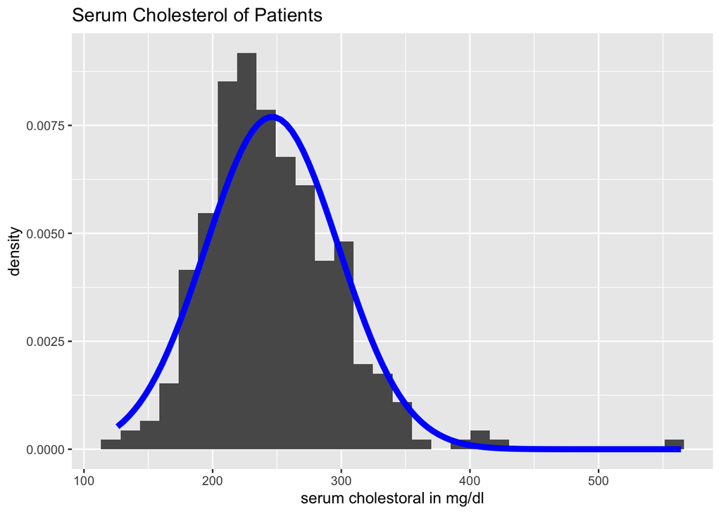

```r
ggplot(heart_data, aes(chol)) +
  geom_histogram(aes(y = ..density..)) +
  stat_function(fun = dnorm,
                args = list(mean = mean(heart_data$chol),
                            sd = sd(heart_data$chol)),
                col = "blue",
                size = 2) +
  xlab("serum cholestoral in mg/dl") +
  ggtitle("Serum Cholesterol of Patients")
```

The mean is around 250mg/dl

```r
summary(heart_data$chol)
```

```
##    Min. 1st Qu.  Median    Mean 3rd Qu.    Max.
##   126.0   211.0   240.0   246.3   274.5   564.0
```

The mean and median are off by 6.3 and there is a slight skew

### Question 4

(5 pts) Test normality of column 5 by performing either a Shapiro-Wilk (tutorial (Links to an external site.)) or Kolmogorov-Smirnof test. Describe what you found.

```r
#shapiro walk test
shapiro.test(heart_data$chol)
```

```
##
##  Shapiro-Wilk normality test
##
## data:  heart_data$chol
## W = 0.94688, p-value = 5.365e-09
```

The p-value is < 0.05 which indicates that chol data is not normally distributed

### Question 5

(5 pts) Identify any outliers for the columns using a z-score deviation approach,i.e., consider any values that are more than 2 standard deviations from the mean as outliers. Which are your outliers for each column? What would you do? Summarize potential strategies in your notebook.

```r
#Compute z
numeric_data <- heart_data %>% #outliers are not calculated for categorical variables
  dplyr::select(age, trestbps, chol, thalach, oldpeak)
outliers_list <- list() #list of outliers for each column
for (i in 1:ncol(numeric_data)){
  z <- abs((mean(numeric_data[ ,i]) - numeric_data[ ,i])/sd(numeric_data[ ,i]))
  outliers <- numeric_data[which(z > 2), ]
  outliers_df <- as.data.frame(outliers[ ,i])
  outliers_list <- c(outliers_list, outliers_df)
}
names(outliers_list) <- colnames(numeric_data)
outliers_list
```

```
## $age
##  [1] 34 35 29 34 74 76 35 35 77 35
##
## $trestbps
##  [1] 172  94 178 180  94 170 170 180 200 170 174 192 178 180 170
##
## $chol
##  [1] 354 417 360 141 564 394 126 353 407 409 131
##
## $thalach
##  [1] 202  96  99  97 103  96  88  95 103  71  90
##
## $oldpeak
##  [1] 3.5 4.2 3.6 3.4 3.6 6.2 3.6 4.0 5.6 4.0 4.2 3.8 3.4 3.6 4.4 4.0 3.4
```

The columns age, trestbps, chol, thalach and oldpeak all have outliers. Some strategies are to remove outliers or to normalize the data by z-score or min-max.

### Question 6

(3 pts) Normalize all columns using z-score standardization.

```r
z_std<-function(x){
  return(abs((mean(x) - x)/sd(x)))
}

heart_data_n<-as.data.frame(apply(heart_data,2, z_std))
head(heart_data_n)
```

```
##         age       sex         cp   trestbps       chol       fbs   restecg
## 1 0.9506240 0.6798805 1.96986425 0.76269408 0.25591036 2.3904835 1.0041707
## 2 1.9121497 0.6798805 1.00092128 0.09258463 0.07208025 0.4169448 0.8974776
## 3 1.4717230 1.4659924 0.03197832 0.09258463 0.81542377 0.4169448 1.0041707
## 4 0.1798773 0.6798805 0.03197832 0.66277043 0.19802967 0.4169448 0.8974776
## 5 0.2899839 1.4659924 0.93696465 0.66277043 2.07861109 0.4169448 0.8974776
## 6 0.2899839 0.6798805 0.93696465 0.47760118 1.04694656 0.4169448 0.8974776
##      thalach   exang   oldpeak     slope       ca      thal    target
## 1 0.01541728 0.69548 1.0855423 2.2708221 0.713249 2.1453238 0.9130188
## 2 1.63077374 0.69548 2.1190672 2.2708221 0.713249 0.5120748 0.9130188
## 3 0.97589950 0.69548 0.3103986 0.9747397 0.713249 0.5120748 0.9130188
## 4 1.23784920 0.69548 0.2063639 0.9747397 0.713249 0.5120748 0.9130188
## 5 0.58297496 1.43311 0.3786180 0.9747397 0.713249 0.5120748 0.9130188
## 6 0.07189928 0.69548 0.5508722 0.6480412 0.713249 2.1453238 0.9130188
```

### Question 7

(4 pts) The data set is sorted, so creating a validation data set requires random selection of elements. Create a stratified sample where you randomly select 15% of each of the cases for each payment type to be part of the validation data set. The remaining cases will form the training data set.

```r
library(rsample)
split_strat  <- initial_split(heart_data_n, prop = 0.85,
                              strata = "target")
train_strat  <- training(split_strat)
val_strat   <- testing(split_strat)

train_target <- train_strat$target
val_target <- val_strat$target

train_data <- train_strat[, 1:13]
val_data <- val_strat[, 1:13]
```

### Question 8

(20 pts) Implement the k-NN algorithm in R (do not use an implementation of k-NN from a package) and use your algorithm with a k=5 to predict the chance of heart attack for the following new case:

age = 50 | sex = 1 | cp = 2 | trestbps = 140 | chol = 249 | fbs = 1 | restecg = 0 | thalach = 150 | exang = 1 | oldpeak = 1.3 | slope = 1 | ca = 0 | thal = 1

Use only the training data set. Note that you need to normalize the values of the new cases the same way as you normalized the original data. If the data set is too large to handle on your computer, then create a smaller training data set by randomly sampling the original data set.

```r
#calculate euclidean dist
euc_dist <- function(d1, d2){
  d = 0
  for(i in c(1:(length(d1)-1) ))
  {
    d = d + (d1[[i]]-d2[[i]])^2
  }
  d = sqrt(d)
  return(d)
}

knn_predict <- function(Train, Test, k){
  prediction <- c()

  #loop over test data
  for(i in c(1:nrow(Test))){
    eu_dist =c()
    #loop over train data
    for(j in c(1:nrow(Train))){
      #calculate euclidean dist between test and train data
      eu_dist <- c(eu_dist, unlist(euc_dist(Test[i, ], Train[j, ])))
    }
    #create dataframe with Target and distances
    eu <- data.frame(Target=train_target, eu_dist)
    #sort dataframe to get top K neighbors
    eu <- eu[order(eu$eu_dist),]
    #dataframe with top K neighbors
    eu <- eu[1:k,]

    #get the target that occurs the most
    target <- unique(eu$Target)
    mode <- target[which.max(tabulate(match(eu$Target, target)))]

    prediction <- c(prediction, mode)
  }
  prediction
}
```

```r
pred <- knn_predict(train_data, val_data, k=5)
pred
```

```
##  [1] 0.9130188 1.0916529 0.9130188 0.9130188 0.9130188 0.9130188 0.9130188
##  [8] 0.9130188 0.9130188 0.9130188 0.9130188 1.0916529 0.9130188 0.9130188
## [15] 0.9130188 0.9130188 0.9130188 0.9130188 0.9130188 0.9130188 0.9130188
## [22] 0.9130188 1.0916529 1.0916529 1.0916529 0.9130188 1.0916529 0.9130188
## [29] 1.0916529 0.9130188 1.0916529 0.9130188 1.0916529 1.0916529 0.9130188
## [36] 0.9130188 0.9130188 1.0916529 1.0916529 0.9130188 1.0916529 0.9130188
## [43] 1.0916529 1.0916529 0.9130188 1.0916529
```

```r
#create dataframe with test case
test_case <- data.frame(age = 50, sex = 1, cp = 2, trestbps = 140, chol = 249, fbs = 1, restecg = 0, thalach = 150, exang = 1, oldpeak = 1.3, slope = 1, ca = 0, thal = 1, target = NA)
test_case <- rbind(heart_data, test_case)

#normalize
z_std<-function(x){
  return(abs((mean(x) - x)/sd(x)))
}
test_case_n<-as.data.frame(apply(test_case,2,z_std))

#create test and train data
Test <- test_case_n[nrow(test_case_n),]
Test
```

```
##           age       sex        cp  trestbps       chol     fbs  restecg
## 304 0.4797911 0.6782479 0.9976312 0.4766382 0.05269984 2.36437 1.000859
##        thalach    exang  oldpeak     slope        ca    thal target
## 304 0.01539198 1.425935 0.223885 0.6465301 0.7114817 2.12572     NA
```

```r
test_case_n <- test_case_n[-nrow(test_case_n), ]
test_case_n$target <- heart_data_n$target
head(test_case_n)
```

```
##         age       sex         cp   trestbps       chol       fbs   restecg
## 1 0.9534171 0.6782479 1.96657646 0.76209531 0.25650646 2.3643701 1.0008592
## 2 1.9129993 0.6782479 0.99763117 0.09427596 0.07202523 0.4215544 0.9007733
## 3 1.4720122 1.4695372 0.02868588 0.09427596 0.81694287 0.4215544 1.0008592
## 4 0.1816896 0.6782479 0.02868588 0.66519014 0.19853028 0.4215544 0.9007733
## 5 0.2919364 1.4695372 0.94025941 0.66519014 2.08186615 0.4215544 0.9007733
## 6 0.2919364 0.6782479 0.94025941 0.47663822 1.04884759 0.4215544 0.9007733
##      thalach     exang   oldpeak     slope        ca      thal    target
## 1 0.01539198 0.6989875 1.0865089 2.2708702 0.7114817 2.1257204 0.9130188
## 2 1.63342003 0.6989875 2.1216577 2.2708702 0.7114817 0.5020546 0.9130188
## 3 0.97746271 0.6989875 0.3101474 0.9778100 0.7114817 0.5020546 0.9130188
## 4 1.23984564 0.6989875 0.2074270 0.9778100 0.7114817 0.5020546 0.9130188
## 5 0.58388832 1.4259346 0.3799518 0.9778100 0.7114817 0.5020546 0.9130188
## 6 0.07206899 0.6989875 0.5524766 0.6465301 0.7114817 2.1257204 0.9130188
```

```r
split_strat  <- initial_split(test_case_n, prop = 0.85,
                              strata = "target")
Train_strat  <- training(split_strat)
Val_strat   <- testing(split_strat)

#get target column
Train_target <- Train_strat$target
Val_target <- Val_strat$target

#remove target column
Test_ <-Test[, 1:13]
Train_strat_ <- Train_strat[, 1:13]
Val_strat_ <-Val_strat[,1:13]
```

```r
prediction <- knn_predict(Train_strat_, Test_, k=5)
prediction
```

```
## [1] 1.091653
```

### Question 9

(7pts) Apply the knn function from the class package with k=5 and redo the cases from Question (11). Compare your answers.

```r
library(class)

test_pred <- knn(train = Train_strat_, test = Test_,cl = Train_target, k=5)
head(test_pred)
```

```
## [1] 1.0916529334612
## Levels: 0.913018817076644 1.0916529334612
```

```r
#class package confusion matrix
test_pred <- knn(train = train_data, test = val_data,cl = train_target, k=5)
confusionMatrix(as.factor(test_pred), as.factor(val_target))
```

```
## Confusion Matrix and Statistics
##
##                    Reference
## Prediction          0.913018817076644 1.0916529334612
##   0.913018817076644                20               8
##   1.0916529334612                   5              13
##
##                Accuracy : 0.7174
##                  95% CI : (0.5654, 0.8401)
##     No Information Rate : 0.5435
##     P-Value [Acc > NIR] : 0.01207
##
##                   Kappa : 0.4239
##
##  Mcnemar's Test P-Value : 0.57910
##
##             Sensitivity : 0.8000
##             Specificity : 0.6190
##          Pos Pred Value : 0.7143
##          Neg Pred Value : 0.7222
##              Prevalence : 0.5435
##          Detection Rate : 0.4348
##    Detection Prevalence : 0.6087
##       Balanced Accuracy : 0.7095
##
##        'Positive' Class : 0.913018817076644
##
```

```r
#confusion matrix from knn function
confusionMatrix(as.factor(pred), as.factor(val_target))
```

```
## Confusion Matrix and Statistics
##
##                    Reference
## Prediction          0.913018817076644 1.0916529334612
##   0.913018817076644                20              10
##   1.0916529334612                   5              11
##
##                Accuracy : 0.6739
##                  95% CI : (0.5198, 0.8047)
##     No Information Rate : 0.5435
##     P-Value [Acc > NIR] : 0.05046
##
##                   Kappa : 0.3301
##
##  Mcnemar's Test P-Value : 0.30170
##
##             Sensitivity : 0.8000
##             Specificity : 0.5238
##          Pos Pred Value : 0.6667
##          Neg Pred Value : 0.6875
##              Prevalence : 0.5435
##          Detection Rate : 0.4348
##    Detection Prevalence : 0.6522
##       Balanced Accuracy : 0.6619
##
##        'Positive' Class : 0.913018817076644
##
```

### Question 10

(10 pts) Using kNN from the class package, create a plot of k (x-axis) from 2 to 8 versus accuracy (percentage of correct classifications) using ggplot.

```r
set.seed(1)
accuracy <- c()
for (i in 2:8){
  test_pred <- knn(train = train_data, test = val_data,cl = train_target, k=i)
  cm <- confusionMatrix(as.factor(test_pred), as.factor(val_target))
  acc <- as.numeric(cm$overall[1])
  accuracy <- c(accuracy, acc)
}
accuracy <- as.data.frame(accuracy)
accuracy$k <- c("2", "3", "4", "5", "6", "7", "8")
```

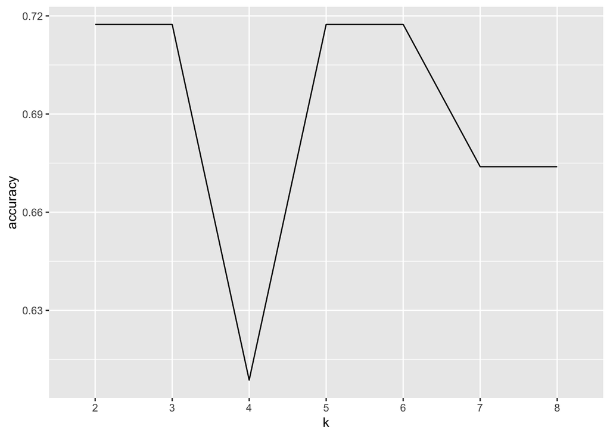

```r
#plot k vs accuracy
ggplot(accuracy, aes(x=k, y=accuracy, group=1)) +
  geom_line()
```

When k=4 the accuracy when using the class package is lowest

## Problem 2 (40 Points)

### Question 1

(0 pts) Investigate the Diamond (Links to an external site.) data from the ggplot2 library.

```r
diamonds_data <- diamonds
str(diamonds_data)
```

```
## tibble [53,940 × 10] (S3: tbl_df/tbl/data.frame)
##  $ carat  : num [1:53940] 0.23 0.21 0.23 0.29 0.31 0.24 0.24 0.26 0.22 0.23 ...
##  $ cut    : Ord.factor w/ 5 levels "Fair"<"Good"<..: 5 4 2 4 2 3 3 3 1 3 ...
##  $ color  : Ord.factor w/ 7 levels "D"<"E"<"F"<"G"<..: 2 2 2 6 7 7 6 5 2 5 ...
##  $ clarity: Ord.factor w/ 8 levels "I1"<"SI2"<"SI1"<..: 2 3 5 4 2 6 7 3 4 5 ...
##  $ depth  : num [1:53940] 61.5 59.8 56.9 62.4 63.3 62.8 62.3 61.9 65.1 59.4 ...
##  $ table  : num [1:53940] 55 61 65 58 58 57 57 55 61 61 ...
##  $ price  : int [1:53940] 326 326 327 334 335 336 336 337 337 338 ...
##  $ x      : num [1:53940] 3.95 3.89 4.05 4.2 4.34 3.94 3.95 4.07 3.87 4 ...
##  $ y      : num [1:53940] 3.98 3.84 4.07 4.23 4.35 3.96 3.98 4.11 3.78 4.05 ...
##  $ z      : num [1:53940] 2.43 2.31 2.31 2.63 2.75 2.48 2.47 2.53 2.49 2.39 ...
```

```r
anyNA(diamonds_data)
```

```
## [1] FALSE
```

There are no missing values

### Question 2

(3 pts) Save the price column in a separate vector/data frame called target_data. Move all the remaining columns into a new data frame called train_data.

```r
target_data <-diamonds_data$price
train_data <- diamonds_data[ , -7]
```

### Question 3

(2 pts) Encode all categorical columns and Normalize all the columns in train_data using min-max normalization.

```r
#change factors to numeric
train_data <- train_data %>% mutate(across(where(is.factor), as.numeric))
str(train_data)
```

```
## tibble [53,940 × 9] (S3: tbl_df/tbl/data.frame)
##  $ carat  : num [1:53940] 0.23 0.21 0.23 0.29 0.31 0.24 0.24 0.26 0.22 0.23 ...
##  $ cut    : num [1:53940] 5 4 2 4 2 3 3 3 1 3 ...
##  $ color  : num [1:53940] 2 2 2 6 7 7 6 5 2 5 ...
##  $ clarity: num [1:53940] 2 3 5 4 2 6 7 3 4 5 ...
##  $ depth  : num [1:53940] 61.5 59.8 56.9 62.4 63.3 62.8 62.3 61.9 65.1 59.4 ...
##  $ table  : num [1:53940] 55 61 65 58 58 57 57 55 61 61 ...
##  $ x      : num [1:53940] 3.95 3.89 4.05 4.2 4.34 3.94 3.95 4.07 3.87 4 ...
##  $ y      : num [1:53940] 3.98 3.84 4.07 4.23 4.35 3.96 3.98 4.11 3.78 4.05 ...
##  $ z      : num [1:53940] 2.43 2.31 2.31 2.63 2.75 2.48 2.47 2.53 2.49 2.39 ...
```

All columns have been changed to numeric

```r
#normalize data
#create function
normalize <- function(x) {
return ((x - min(x)) / (max(x) - min(x))) }
#normalize numeric data
train_data_n <- as.data.frame(lapply(train_data, normalize))
head(train_data_n)
```

```
##         carat  cut     color   clarity     depth     table         x          y
## 1 0.006237006 1.00 0.1666667 0.1428571 0.5138889 0.2307692 0.3677840 0.06757216
## 2 0.002079002 0.75 0.1666667 0.2857143 0.4666667 0.3461538 0.3621974 0.06519525
## 3 0.006237006 0.25 0.1666667 0.5714286 0.3861111 0.4230769 0.3770950 0.06910017
## 4 0.018711019 0.75 0.8333333 0.4285714 0.5388889 0.2884615 0.3910615 0.07181664
## 5 0.022869023 0.25 1.0000000 0.1428571 0.5638889 0.2884615 0.4040968 0.07385399
## 6 0.008316008 0.50 1.0000000 0.7142857 0.5500000 0.2692308 0.3668529 0.06723260
##            z
## 1 0.07641509
## 2 0.07264151
## 3 0.07264151
## 4 0.08270440
## 5 0.08647799
## 6 0.07798742
```

All columns have been normalized

### Question 4

(15 pts) Build a function called knn.reg that implements a regression version of kNN that averages the prices of the k nearest neighbors using a weighted average where the weight is 3 for the closest neighbor, 2 for the second closest and 1 for the remaining neighbors (recall that a weighted average requires that you divide the sum product of the weight and values by the sum of the weights). It must use the following signature:

knn.reg (new_data, target_data, train_data, k)

where new_data is a data frame with new cases, target_data is a data frame with a single column of prices from (2), train_data is a data frame with the features from (2) that correspond to a price in target_data, and k is the number of nearest neighbors to consider. It must return the predicted price.

```r
library(flexclust)
#calculate euclidean dist
euc_dist <- function(d1, d2){
  d = 0
  for(i in c(1:(length(d1)-1) ))
  {
    d = d + (d1[[i]]-d2[[i]])^2
  }
  d = sqrt(d)
  return(d)
}

knn.reg <- function(new_data, target_data, train_data, k){
  forecast <- c()
  #loop over new data
  for(i in c(1:nrow(new_data))){
    eu_dist =c()
    #loop over train data
    for(j in c(1:nrow(train_data))){
      #calculate euclidean dist between new and train data
      eu_dist <- c(eu_dist, unlist(euc_dist(new_data[i, ], train_data[j, ])))
    }
    #create dataframe with price and distances
    eu <- data.frame(price=target_data, eu_dist)
    #sort dataframe to get top K neighbors
    eu <- eu[order(eu$eu_dist),]
    #dataframe with top K neighbors
    eu <- eu[1:k,]

    #add weights to k nearest neighbors
    w <- rep(1, k)
    w[1] <- 3
    w[2] <- 2
    #compute weighted average
    wa <- sum(w* eu$price)/sum(w)
    forecast <- c(forecast, wa)
    }
  forecast
}
```

### Question 5

(4 pts) Forecast the price of this new diamond using your regression kNN using k = 5: carat = 0.63 | cut = Premium | color = E | clarity = VS2 | depth = 59.2 | table = 59.0 | x = 5.86 | y = 5.83 | z = 3.46

```r
#bind data with diamond data
new_data <- data.frame(carat = 0.63, cut = "Premium", color= "E", clarity = "VS2", depth = 59.2, table = 59.0, x = 5.86, y = 5.83, z = 3.46)
new_data_bind <- rbind(diamonds_data[ ,-7], new_data)
new_data_bind <- new_data_bind %>% mutate(across(where(is.factor), as.numeric))

#normalize
new_data_n<-as.data.frame(apply(na.omit(new_data_bind),2, normalize))
head(new_data_n)
```

```
##         carat  cut     color   clarity     depth     table         x          y
## 1 0.006237006 1.00 0.1666667 0.1428571 0.5138889 0.2307692 0.3677840 0.06757216
## 2 0.002079002 0.75 0.1666667 0.2857143 0.4666667 0.3461538 0.3621974 0.06519525
## 3 0.006237006 0.25 0.1666667 0.5714286 0.3861111 0.4230769 0.3770950 0.06910017
## 4 0.018711019 0.75 0.8333333 0.4285714 0.5388889 0.2884615 0.3910615 0.07181664
## 5 0.022869023 0.25 1.0000000 0.1428571 0.5638889 0.2884615 0.4040968 0.07385399
## 6 0.008316008 0.50 1.0000000 0.7142857 0.5500000 0.2692308 0.3668529 0.06723260
##            z
## 1 0.07641509
## 2 0.07264151
## 3 0.07264151
## 4 0.08270440
## 5 0.08647799
## 6 0.07798742
```

```r
#remove last row
new_data <- new_data_n[nrow(new_data_n), ]
data_n <- new_data_n[-nrow(new_data_n), ]
```

```r
#forecast price of new diamond
forecast = knn.reg(new_data, target_data, train_data, 5)
forecast
```

```
## [1] 3844.625
```

### Question 6

(5 pts) Calculate the Mean Squared Error (MSE) using a random sample of 10% of the data set as test data.

```r
#get 10% of data
data_n$price <- diamonds_data$price #add price column
rsample <- sample.int(n = nrow(data_n), size = floor(.1*nrow(data_n)), replace = F) #take sample
train_data <- data_n[rsample, ]
rsample <- sample.int(n = nrow(train_data), size = floor(.1*nrow(train_data)), replace = F) #take sample
new_data <- train_data[rsample, ]

#get target data
target_data <-train_data$price
price_new_data <- new_data$price

#remove price
train_data <- train_data[ , -10]
new_data <- new_data[ ,-10]
```

```r
forecast = knn.reg(new_data, target_data, train_data, 5)
head(forecast)
```

```
## [1]  747.000 6593.375 4170.250 3939.875 2785.250 4441.250
```

```r
#calculate MSE
error <- price_new_data - forecast
MSE <- mean(as.numeric(lapply(error, function(x) {x**2})))
MSE
```

```
## [1] 367979.2
```

## Problem 3 (10 Points)

### Question 1

(0 pts) Download and Extract the data set of Home prices of Kings County (USA)

```r
house_data <- read.csv("/Users/taylorjohnson/Downloads/kc_house_data.csv", stringsAsFactors =F)
```

### Question 2

(3 pts) Build a new data frame with the four columns: tper, year, month, avg_price_sq_ft where tper is the time period starting at 1 (e.g., 1, 2, 3, 4, …), year and month are the year and month of the sale of a property extracted from the column date and avg_price_sq_ft is the average price per square foot of living space for all properties sold that month. The data set should contain the sales in order from least recent to most recent, i.e., the first column after the header column should be the property sold the furthest in the past.

```r
house_data_new <- house_data %>%
  mutate(year = gsub("(^\\d{4}).*", "\\1", house_data$date)) %>%
  mutate(month = gsub("(^[0-9]{4})(\\d{2}).*", "\\2", house_data$date)) %>%
  group_by(month, year) %>%
  summarize(avg_price_sq_ft = mean(price/sqft_living)) %>%
  arrange(year, month)  %>%
  select(year, month, avg_price_sq_ft)
house_data_new$tper <- seq.int(nrow(house_data_new))
head(house_data_new)
```

```
## # A tibble: 6 x 4
## # Groups:   month [6]
##   year  month avg_price_sq_ft  tper
##   <chr> <chr>           <dbl> <int>
## 1 2014  05               263.     1
## 2 2014  06               265.     2
## 3 2014  07               260.     3
## 4 2014  08               260.     4
## 5 2014  09               260.     5
## 6 2014  10               263.     6
```

### Question 3

(3 pts) Plot the average sales price per month as a time series line graph.

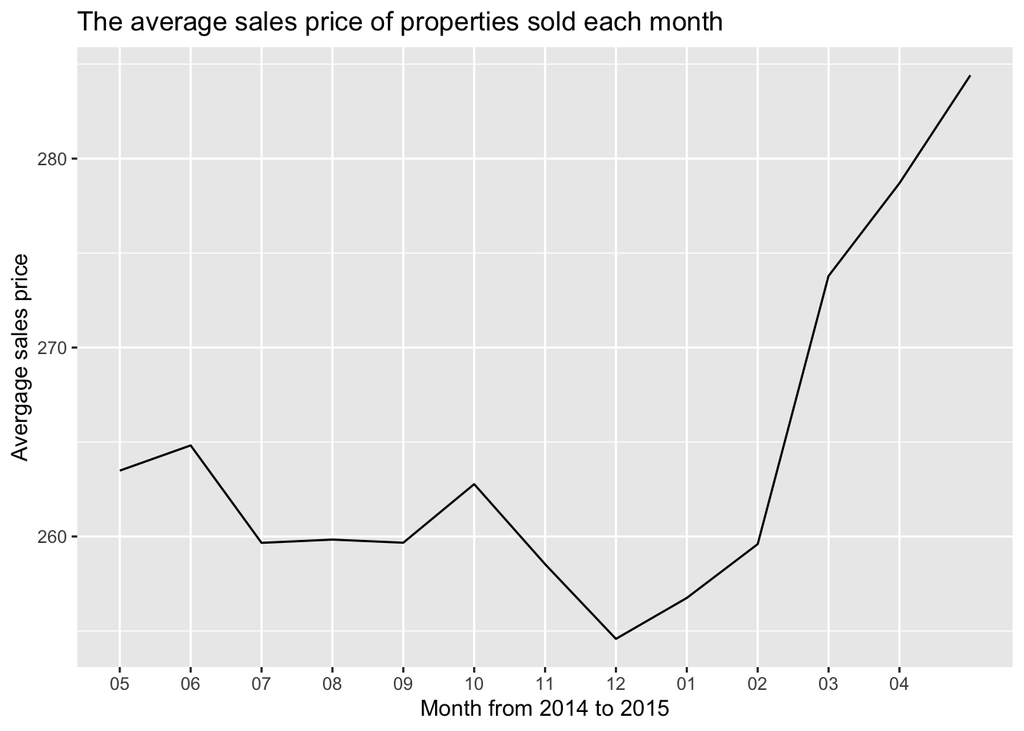

```r
months <- as.character(house_data_new$month)
ggplot(house_data_new, aes(tper, avg_price_sq_ft)) +
  geom_line() +
  xlab("Month from 2014 to 2015") +
  ylab("Avergage sales price") +
  ggtitle("The average sales price of properties sold each month ") +
  scale_x_discrete(limits= months)
```

The average price dips after 10/2014 and then increases after 12/2014 and reaches the highest average price in 05/2015.

### Question 4

(6 pts) Forecast the average sales price for the next month is the time series using a weighted moving average of the most recent 3 months with weights of 4, 3, and 1.

```r
w <- c(1,3,4)
house_filt <- house_data_new[11:13,]
wa <- sum(w* house_filt$avg_price_sq_ft)/sum(w)
wa
```

```
## [1] 280.9403
```

The average price forecast for the next month is $280.94